# Olympic Medal Predictions

### Introduction

This was a personal project created to be presented at a project fair to students and faculty during my time at school.

The Olympic Games are the leading international sporting events where athletes from every country are given the opportunity to compete in a wide variety of disciplines to earn rewards and recognition for themselves and their country. The summer and winter Olympics are held every two years, in alternating order, in host cities that are selected years in advance. Male and female athletes compete for bronze, silver, and gold medals that reflect third, second, and first place respectively.

### The Data

The Olympic Games are the leading international sporting events where athletes from every country are given the opportunity to compete in a wide variety of disciplines to earn rewards and recognition for themselves and their country. The summer and winter Olympics are held every two years, in alternating order, in host cities that are selected years in advance. Male and female athletes compete for bronze, silver, and gold medals that reflect third, second, and first place respectively.

### Objective

The goal is to analyze how the socioeconomic factors in countries influence that country’s overall success at the Olympic Games, measured by their medal count. The analysis will also contain modeling to predict a country’s success in order to determine the most important socioeconomic factors to success. This analysis can give an understanding as to why some countries dominate events while others are entirely absent from medalling.

### Load Packages

```r
library(ggplot2)
library(tidyverse)
library(mice)
library(caret)
library(Matrix)
library(glmnet)
library(readr) # CSV file I/O, e.g. the read_csv function
library(plyr)
library(rworldmap)
library(repr)
library(MLmetrics)
library(tree)
library(randomForest)
library(corrplot)
library(RColorBrewer)
library(rgeos)
library(rnaturalearth)
library(rnaturalearthdata)
```

### Read in Data

```r
summer <- read_csv(url("https://raw.githubusercontent.com/greyson2121/Code/main/Predict%20Future%20Sales%20Kaggle%20Competition/Data/summer.csv"))
winter <- read_csv(url("https://raw.githubusercontent.com/greyson2121/Code/main/Predict%20Future%20Sales%20Kaggle%20Competition/Data/winter.csv"))
dic <- read_csv(url("https://raw.githubusercontent.com/greyson2121/Code/main/Predict%20Future%20Sales%20Kaggle%20Competition/Data/dictionary.csv"))
wid <- read.csv("WDIData.csv")

summer$season <- "summer"
winter$season <- "winter"
olym <- as.data.frame(rbind(summer,winter))
```

### Data Cleaning

Given that the world development indicator dataset includes thousands of different indicators for each country, it is necessary to subset to a few that are relevant and widely available for the countries in the olympics dataset.

```r
### Choose the development indicator
Indicators <- c("SP.DYN.CDRT.IN","SP.POP.TOTL","SP.POP.GROW","EN.POP.DNST","AG.LND.TOTL.K2","NY.GDP.MKTP.KD.ZG","NY.GDP.MKTP.CD","EN.ATM.CO2E.PC",
                "SP.DYN.CBRT.IN","SP.DYN.LE00.IN","SP.DYN.IMRT.IN","SP.RUR.TOTL","FI.RES.TOTL.CD","NE.TRD.GNFS.ZS","SP.URB.TOTL","AG.PRD.FOOD.XD")
```

Next

```r
# save the countries that have participated in at least one Olympic games and the years that the Olympics have taken place

olympicyears <- paste("X",unique(olym$Year),sep="")
olympiccountries <- unique(olym$Country)
```

The WDI dataset is subset to include only the variables that were specified, countries that have participated in the Olympics, and years where the Olympics were held.

```r
wdi <- filter(wid,Country.Code %in% olympiccountries)
wdi2 <- filter(wdi, Indicator.Code %in% Indicators)
wdi3 <- wdi2[,colnames(wdi2) %in% c(colnames(wdi2)[1:4],olympicyears)]
wdi3 <- wdi3[,-5]

wdilong <- gather(wdi3,Year,Value,X1964:X2014)
wdilong$Year <- substring(wdilong$Year,2)
wdilong <- wdilong[,-4]
wdifinal <- spread(wdilong,Indicator.Name,Value)
```

Only Olympic games held past 1964 will be used in the analysis, as many countries (specifically smaller ones) lack data in the WDI set prior to 1960. In order to judge the success of each country, a medal scoring system will be used where bronze is equal to 1 point, silver is equal to 2 points, and gold is equal to 3 points.

```r
olym2 <- as.data.frame(olym[olym$Year %in% 1964:2020,])


medals <- olym2 %>% group_by(Country,Year) %>% dplyr::count(Medal)
medals <- medals[-c(1,2),]
medals2 <- spread(medals,Medal,n)
medals2 <- as.data.frame(medals2)
medals2[is.na(medals2)] <- 0

medals2$points <- medals2$Bronze + (2*medals2$Silver) + (3*medals2$Gold)
```

Finally, we can merge the Olympics and WDI datasets. The columns were also reorganized and renamed manually.

```r
df2 <- merge(medals2,wdifinal,by.x=c("Country","Year"),by.y=c("Country.Code","Year"))
df <- df2[,c(7,1,2,3,5,4,6,8:15,18,16,17,19:23)]

colnames(df) <- c("Country","Country.Code","Year","Bronze","Silver","Gold","Points","Birth.Rate",
                  "C02.Emissions","Death.Rate","Food.Production","GDP","GDP.Growth","Land.Area","Expectancy","Population.Growth", "Infant.Mortality","Population.Density","Population","Rural.Population","Total.Reserves","Trade.Percentage","Urban.Population")
df$Year <- as.numeric(df$Year)
df[8:23] <- apply(df[,8:23],2,as.numeric)
```

```r
### Missing values
sum(is.na(df2))/(16*657)*100

### Imputation
dfimpute <- as.matrix(df[,c(3,8:23)])
dfnew <- mice(dfimpute,method="cart")

df[,c(3,8:23)] <- complete(dfnew)

regression <- df[,7:23]
```

### Exploratory Data Analysis

First we will look at the total number of each events held at each Olympics.

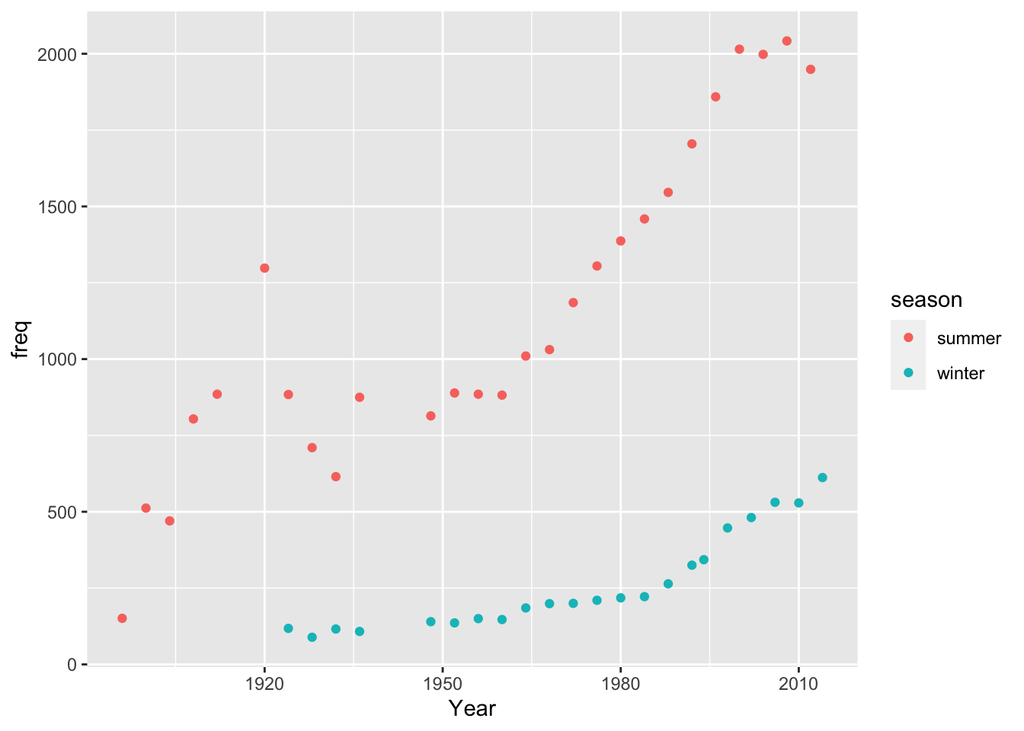

```r
### Total events over time
totalevents <- plyr::count(olym[,c(1,10)])
ggplot(data=totalevents,aes(x=Year,y=freq,color=season)) + geom_point()
```

We can also look at world maps of medal points and per capita GDP to get a visual indication of how Olympic success and individual economic prosperity are related. Countries who have never won a medal are shaded in grey.

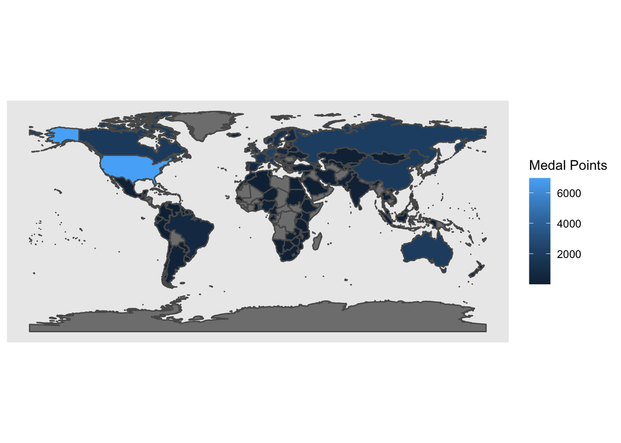

```r
### Maps
country <- aggregate(medals2$points,by=list(medals2$Country),sum)
colnames(country) <- c("Country","Medals")
country2 <- merge(country,dic,by.x="Country",by.y="Code")


# define colors
palette = colorRampPalette(brewer.pal(n=7, name='Oranges'))(7)
palette = c("white", palette)

# create map
world <- ne_countries(scale = "medium", returnclass = "sf")
country3 <- merge(world, country2, by.x = "name",by.y="Country.y",all.x=TRUE)

worldmedalsmap <- ggplot() +geom_sf(data = country3, aes(fill = Medals)) +
  labs(fill = "Medal Points") +
  theme(panel.grid.major = element_blank(),
        panel.grid.minor = element_blank())

worldgdpmap <- ggplot() +geom_sf(data = country3, aes(fill = `GDP per Capita`)) +
  labs(fill = "GDP per Capita") +
  theme(panel.grid.major = element_blank(),
        panel.grid.minor = element_blank())

worldmedalsmap
```

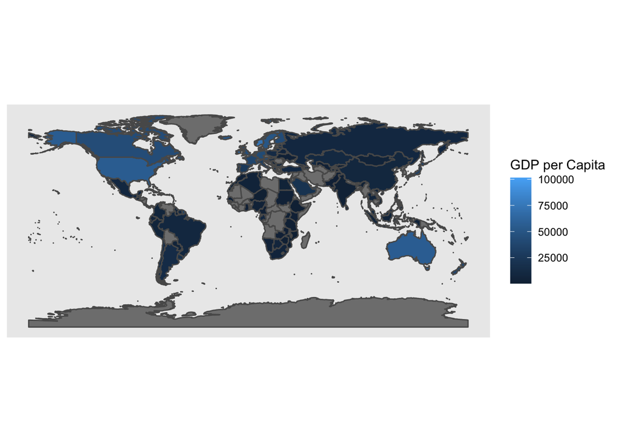

```r
worldgdpmap
```

I also was intereseted in how gender reperesentation at the Olympics has changed over time. In both the winter and summer games, the number of female participants has rapidly increased in the last 100 years and is comparable to the male participation.

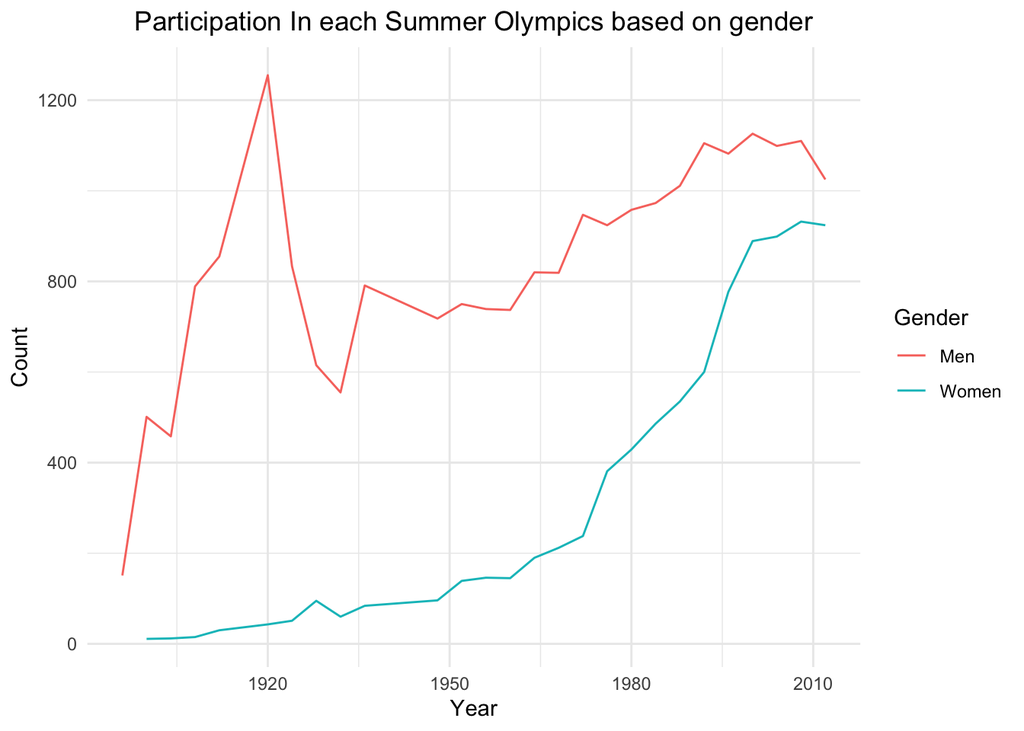

```r
par(mfrow=c(2,1))
summer%>%
  group_by(Gender,Year) %>%
  dplyr::count() %>%
  ggplot() + geom_line(aes(x= Year, y=n, group = Gender, color = Gender)) +
  labs(title = 'Participation In each Summer Olympics based on gender',y="Count")+
  theme_minimal() + theme(plot.title = element_text(hjust = 0.5))
```

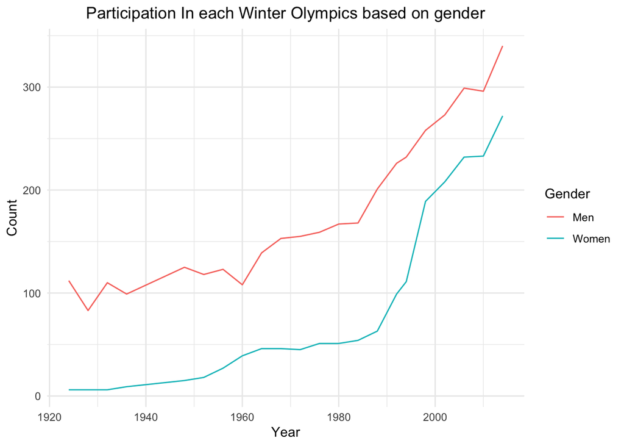

```r
winter%>%
  group_by(Gender,Year) %>%
  dplyr::count() %>%
  ggplot() + geom_line(aes(x= Year, y=n, group = Gender, color = Gender)) +
  labs(title = 'Participation In each Winter Olympics based on gender',y="Count")+
  theme_minimal()+ theme(plot.title = element_text(hjust = 0.5))
```

Each individual event is classified into a discipline which can be thought of as a category. The most common disciplines are found below.

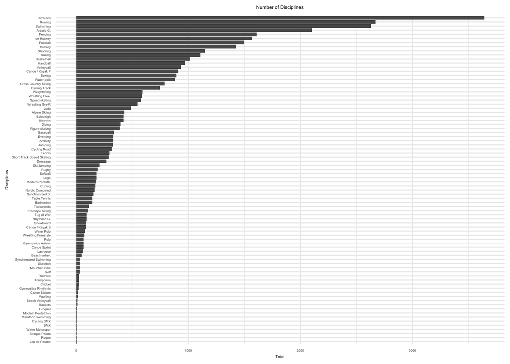

```r
olym%>%
  select(Discipline) %>%
  mutate(Discipline = str_split(Discipline,',')) %>%
  unnest(Discipline) %>%
  group_by(Discipline) %>%
  dplyr::count() %>%
  arrange(desc(n)) %>%
  ggplot() + geom_col(aes(y = reorder(Discipline,n), x = n)) +
  labs(title = 'Number of Disciplines',x = 'Total',y = 'Disciplines') +
  theme_minimal() + theme(plot.title = element_text(hjust = 0.5)) +
  theme(text = element_text(size=4))
```

The winningest countries and athletes were also found.

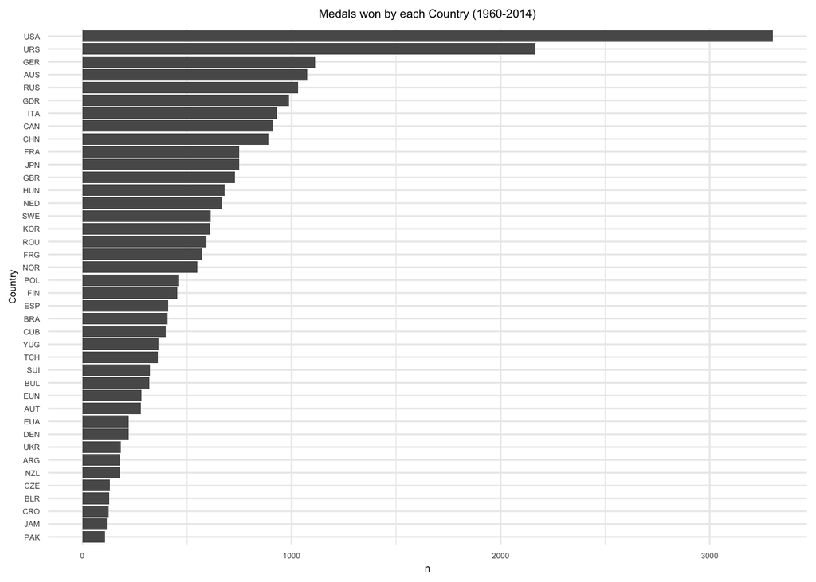

```r
### Medals won by country
olymsub <- olym[olym$Year %in% 1960:2020,]
olymsub%>%
  filter(!str_detect(Country,',')) %>%
  group_by(Country) %>%
  dplyr::count() %>%
  arrange(desc(n)) %>%
  head(40) %>%
  ggplot() + geom_col(aes(y = reorder(Country,n), x = n)) +
  labs(title = 'Medals won by each Country (1960-2014)',y="Country") +
  theme_minimal() + theme(plot.title = element_text(hjust = 0.5)) +
  theme(text = element_text(size=6))
```

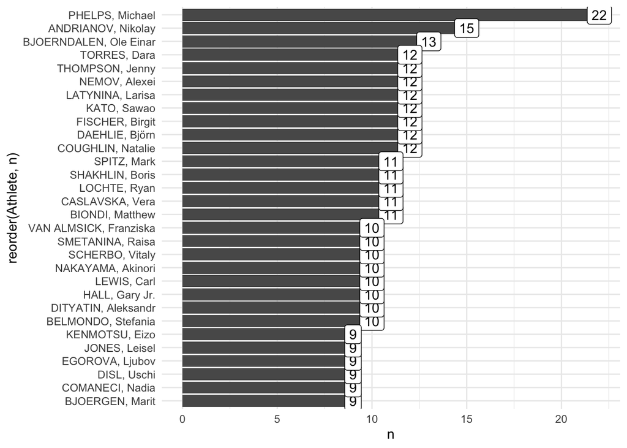

```r
### Most medals wont by athletes

olymsub%>%
  group_by(Athlete) %>%
  dplyr::count() %>%
  arrange(desc(n)) %>%
  head(30) %>%
  ggplot() + geom_col(aes(y = reorder(Athlete,n), x = n)) +
  geom_label(aes(y = reorder(Athlete,n,fill="rep"), x = n, label = n)) +
  theme_minimal() + theme(plot.title = element_text(hjust = 0.5))
```

The plot below shows how many events have been held in total in each of the cities that have hosted an Olympics games.

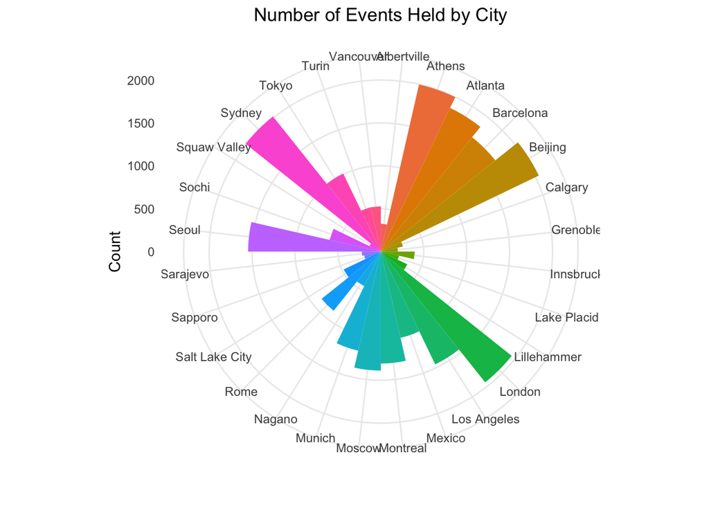

```r
### Proportion of events held by each city
pie <- ggplot(olymsub, aes(x=factor(City), fill = factor(City))) + geom_bar(width = 1) +
  labs(title="Number of Events Held by City",y="Count",x="",legend="")
pie + coord_polar() +theme_minimal()+ theme(legend.position = "none") + theme(plot.title = element_text(hjust = 0.5))
```

In order to find any potential sources of multicollinearity, I used a correlation plot of the predictor variables.

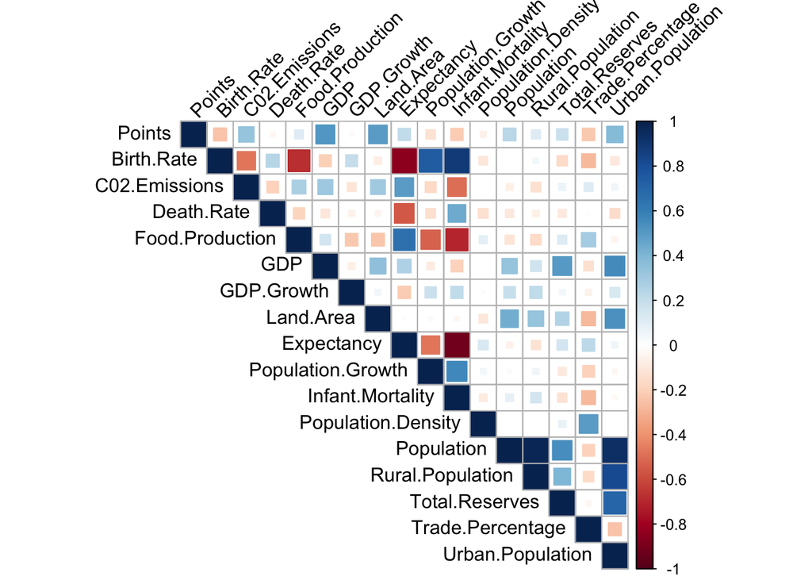

```r
### corrplot
df.cor <- cor(df[7:23])
par(mfrow=c(1,1))
corrplot(df.cor,is.corr = TRUE,method="square",type="upper",tl.srt=45,tl.col="black")
```

Lastly I wanted to determine if any transformations needed to be applied to the predictor variables. I used a boxplot of the scaled variables (centered at 0 with standard deviation of 1) to check the range and number of outliers for each variable. There were a significant amount of outliers for some of the predictor variables, so a log transformation may be useful in our analysis.

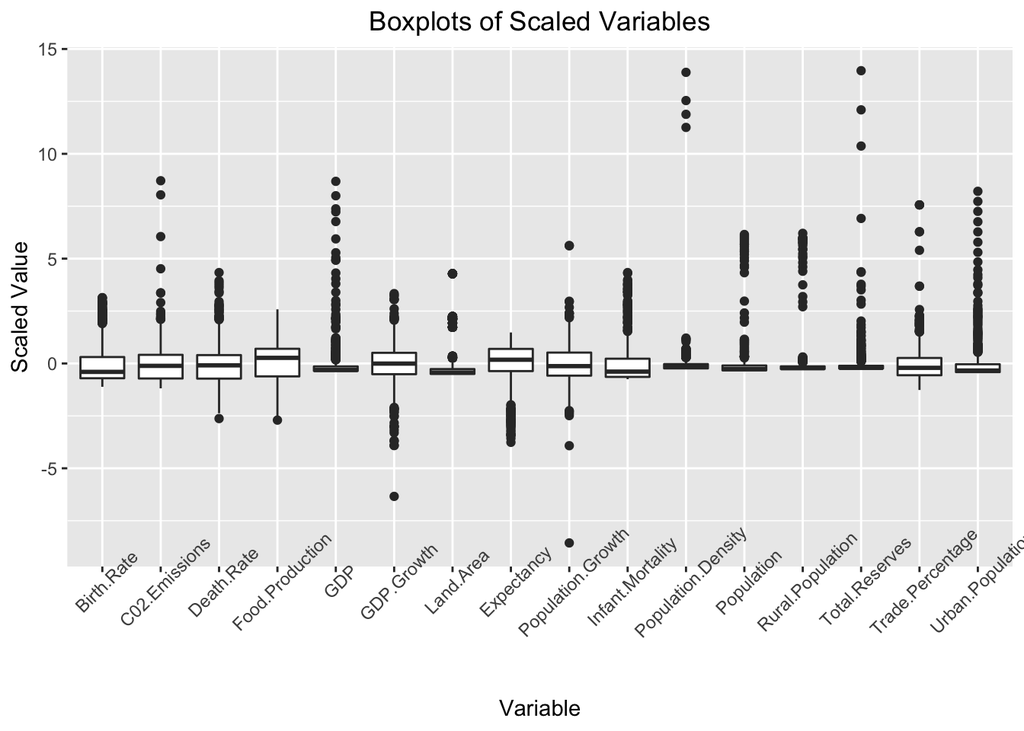

```r
###Boxplots
box <- as.data.frame(scale(df[,8:23]))


ggplot(stack(box),aes(x=ind,y=values)) + geom_boxplot()+ theme(plot.title = element_text(hjust = 0.5),axis.text.x = element_text(angle = 45))+
  labs(title="Boxplots of Scaled Variables",x="Variable",y="Scaled Value")
```

### Analysis

I decided to try four different models: ridge regression, lasso regression, decision tree, and random forest. I wanted to test a few models, specifically lasso and random forest, that would drop variables if they were insignificant due to the multicollinearity we saw in the correlation plot. I also tested each model with the standardized data and the log of the standardized data. In each of the models tested, the data was split into training (80%) and testing (20%) sets. MSE was the metric used to determine the effectiveness of each model.

So, the first step is to create a second data frame with the log of our predictor variables.

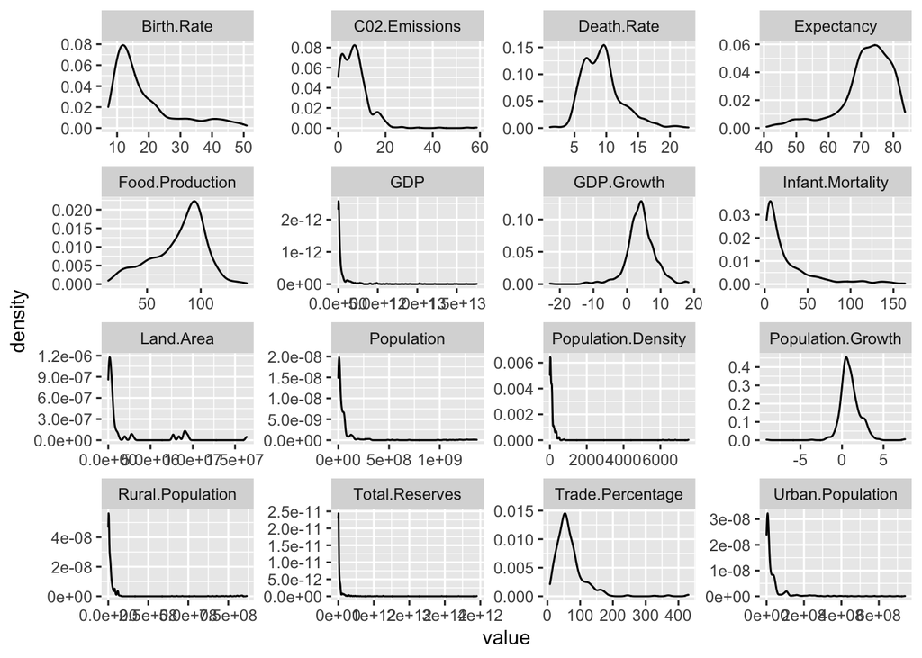

```r
###  Creation of dataset with log of predictors
dflog <- df


### For variables that have values below 0, a started log was used
for (i in 8:23){
  if(min(df[,i])==0){
    dflog[,i] <- dflog[,i] + 1
  }
  if (min(df[,i])<0){
    dflog[,i] <- dflog[,i] + abs(min(dflog[,i])) + 1
  }
}

min(dflog[,16] + abs(min(dflog[,16])) + 1)
dflog[8:23] <- log(dflog[,8:23])

df[,8:23] %>%
  gather() %>%
  ggplot(aes(value)) +  facet_wrap(~ key, scales = "free") +geom_density()
```

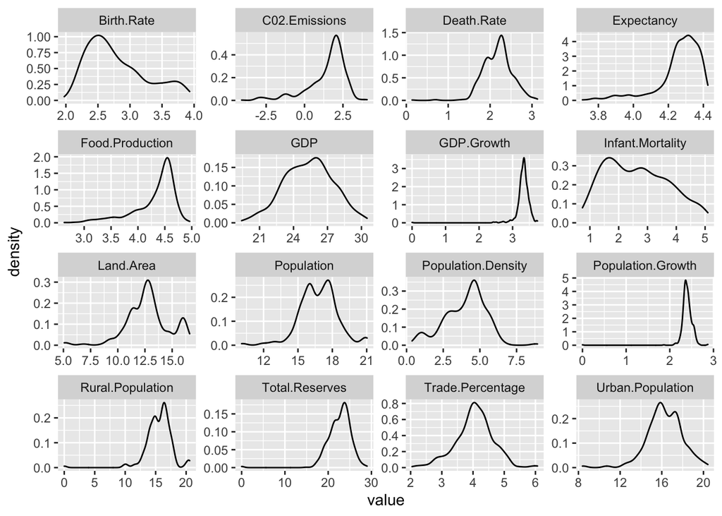

```r
dflog[,8:23] %>%
  gather() %>%
  ggplot(aes(value)) +  facet_wrap(~ key, scales = "free") +geom_density()
```

```r
regression.log <- dflog[,7:23]
summary(lm(Points~.,data=regression.log))


min(dflog$Total.Reserves <- dflog$Total.Reserves + abs(min(dflog$Total.Reserves)) + 1)
```

Next we can split the data into training and testing sets.

```r
index <- sample(nrow(df),nrow(df)*.8)
traintest <- as.data.frame(cbind(df[index,7],scale(df[index,8:23])))
colnames(traintest)[1] <- "Points"
test <- as.data.frame(cbind(df[-index,7],scale(df[-index,8:23])))
colnames(test)[1] <- "Points"

X <- sparse.model.matrix(as.formula(paste("Points ~", paste(colnames(df[,8:23]),sep = "", collapse=" +"))), data = traintest)
y <- traintest$Points
Xtest <- sparse.model.matrix(as.formula(paste("Points ~", paste(colnames(df[,8:23]),sep = "", collapse=" +"))), data = test)
```

```r
### Ridge
cv.ridge <- cv.glmnet(X, y, alpha = 0)
best.lam <- cv.ridge$lambda.min

ridge <- glmnet(X,y,alpha=0,lambda = best.lam)

ridge.R2 <- ridge$dev.ratio

ridge.predictions <- predict(ridge,newx=Xtest)
ridge.MSE <- MSE(ridge.predictions,test$Points)

### Lasso
cv.lasso <- cv.glmnet(X, y, alpha = 1)
best.lam2 <- cv.lasso$lambda.min

lasso <- glmnet(X,y,alpha=1,lambda = best.lam2)

lasso.R2 <- lasso$dev.ratio

lasso.predictions <- predict(lasso,newx=Xtest)
lasso.MSE <- MSE(lasso.predictions, test$Points)

### ridge regression with log
traintest2 <- as.data.frame(cbind(dflog[index,7],scale(dflog[index,8:23])))
colnames(traintest2)[1] <- "Points"
test2 <- as.data.frame(cbind(dflog[-index,7],scale(dflog[-index,8:23])))
colnames(test2)[1] <- "Points"

X2 = sparse.model.matrix(as.formula(paste("Points ~", paste(colnames(df[,8:23]),sep = "", collapse=" +"))), data = traintest2)
y2 <- traintest2$Points
Xtest2 <- sparse.model.matrix(as.formula(paste("Points ~", paste(colnames(dflog[,8:23]),sep = "", collapse=" +"))), data = test)

cv.ridge.log <- cv.glmnet(X2, y2, alpha = 0)
best.lam.log <- cv.ridge$lambda.min

ridge.log <- glmnet(X2,y2,alpha=0,lambda = best.lam)

ridge.log$dev.ratio

ridge.log.predictions <- predict(ridge.log,Xtest2)
ridge.log.MSE <- MSE(ridge.log.predictions,test2$Points)

### Lasso with logs
cv.lasso.log <- cv.glmnet(X2, y2, alpha = 1)
best.lam.log2 <- cv.ridge$lambda.min

lasso.log <- glmnet(X2,y2,alpha=1,lambda = best.lam.log2)

lasso.log$dev.ratio

lasso.log.predictions <- predict(lasso.log,Xtest2)
lasso.log.MSE <- MSE(lasso.log.predictions,test2$Points)
```

```r
### Decision Tree
tree <- tree(Points~., data=traintest)
tree.cv <-cv.tree(tree,K=10)

best.size <- tree.cv$size[which.min(tree.cv$dev)]

tree.best <- prune.tree(tree,best=best.size)

tree.predictions <- predict(tree.best,test)
tree.MSE <- MSE(tree.predictions,test$Points)

### Decision Tree with log
tree.log <- tree(Points~., data=traintest2)
tree.cv.log <-cv.tree(tree.log,K=10)

best.size.log <- tree.cv.log$size[which.min(tree.cv.log$dev)]

tree.best.log <- prune.tree(tree.log,best=best.size.log)

tree.predictions.log <- predict(tree.best,test)
tree.MSE.log <- MSE(tree.predictions.log,test2$Points)
```

```r
### Random Forest
rf <- randomForest(Points~.,data=traintest)
forest.predictions <- predict(rf,test)

rf.MSE <- MSE(forest.predictions,test$Points)

#### Random forest with logs
rf.log <- randomForest(Points~.,data=traintest2)
forest.predictions.log <- predict(rf.log,test2)

rf.MSE.log <- MSE(forest.predictions.log,test2$Points)

rsq <- function (x, y) cor(x, y) ^ 2
rsq(forest.predictions,test2$Points)
```

### Results

```r
### MSE
mse <- c(ridge.MSE,lasso.MSE,tree.MSE,rf.MSE)
mselog <- c(ridge.log.MSE,lasso.log.MSE,tree.MSE.log,rf.MSE.log)

mse.df <- data.frame(mse,mselog)
colnames(mse.df) <- c("MSE","MSE with logs")
rownames(mse.df) <- c("Ridge","Lasso","Tree","Random Forest")

mse.df
```

[output not shown]

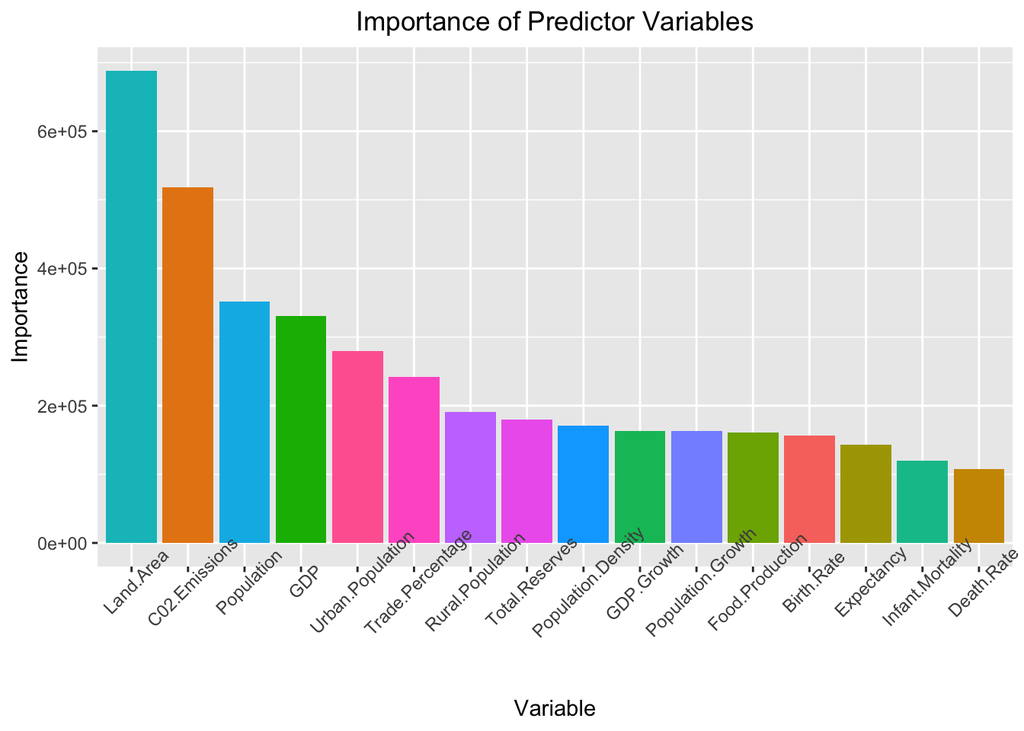

```r
impor <- as.data.frame(importance(rf.log))
impor$Variable <- rownames(impor)
impor2 <- impor[order(impor$IncNodePurity,decreasing=TRUE),]


importance.plot <- ggplot(impor2) + geom_col(aes(x=reorder(Variable,-IncNodePurity),y=IncNodePurity,fill=Variable)) +
  labs(title="Importance of Predictor Variables",x="Variable",y="Importance")

importance.plot+ theme(legend.position = "none") + theme(plot.title = element_text(hjust = 0.5),axis.text.x = element_text(angle = 45))
```